# Simulaciones y modelos generales lineales

Javier Fernández-López

5/3/2022

A menudo, los investigadores que trabajan con la naturaleza deben confiar en estudios observacionales, es decir, analizar los **patrones** que pueden ser observados en el campo e intentar inferir los **procesos** que los han producido. Un investigador podría, a partir del patrón de las localizaciones de presencia de una especie y su relación con ciertas variables ambientales, inferir el proceso mediante el cual ciertas circunstancias ambientales condicionan la distribución de la misma. Por esta razón y desde un punto de vista didáctico, para comprender los modelos de distribución de las especies, puede resultar eficaz utilizar el enfoque en sentido contrario: **simular** el proceso que genera el patrón de distribución e intentar inferirlo a partir de los patrones observados.  
En esta práctica aprenderemos a simular la distribución de una especie *virtual* utilizando un proceso de puntos de Poisson no homogéneo (IPP o IPPP del inglés: Inhomogeneous Poisson (Point) Process). Después, realizaremos un muestreo aleatorio de nuestra población y ajustaremos un **modelo** lineal para comprobar si somos capaces de **comprender** el efecto de nuestras covariables y de **predecir** la distribución de nuestra especie.

# Simulación de un Proceso de Poisson no Homogéneo

Vamos a simular una población de pinzón vulgar *Fringilla coelebs*, un ave principalmente forestal que en la Península Ibérica se alimenta de insectos pero también de yemas y brotes, frutos carnosos o semillas. Nuestro área de estudio será un sector cuadrado de 100 x 100 kilómnetros situado en la Península Ibérica dividido en cuadrículas de 1 km². Simularemos un proceso mediante el cual la abundancia de pinzones esté condicionada por la distancia a un punto de agua y por la cobertura forestal. En hábitats mediterráneos los puntos de agua actúan como atractores de todo tipo de fauna y recursos debido al frecuente estrés hídrico al que están sometidos estos ambientes. La cobertura forestal proporciona al pinzón tanto refugio como una fuente de alimento debido a los insectos, frutos y semillas que están asociados a los bosques.

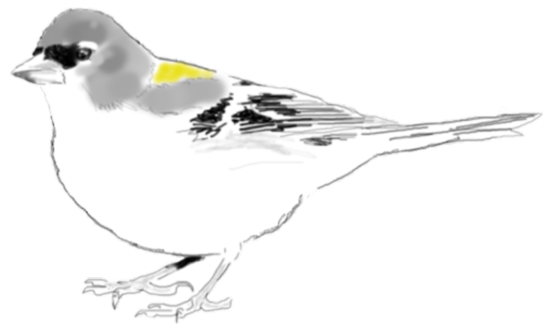

Dibujo: [José Luis Tellería](https://scholar.google.es/citations?user=r6kE5m0AAAAJ&hl=es)

En primer lugar instalaremos y cargaremos los paquetes que vamos a necesitar en esta práctica.

```r
set.seed(123)
#install.package("raster")
library(raster)
library(spatstat)
library(ggplot2)
```

A continuación crearemos las dos covariables o variables predictoras que van a gobernar la abundancia de pinzones en nuestro área de estudio, que de momento dejaremos vacía de pinzones.

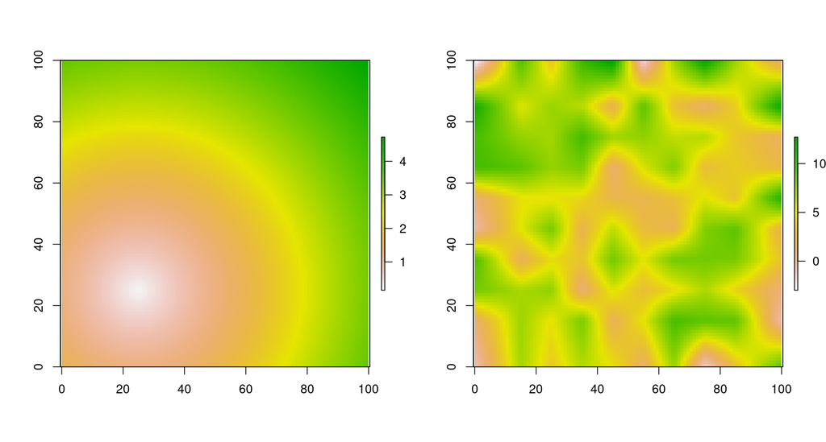

```r
# Creamos un raster de 100 x 100 cuadrículas que dejaremos vacío por el momento
sarea <- raster(nrows = 100, ncols = 100, xmn = 0, xmx = 100, ymn = 0, ymx = 100)
# Creamos un punto de agua en la coordenada X=25 Y=25 y a partir de este punto
# generamos una capa de distancia al punto de agua "dwat"
dwat <- scale(distanceFromPoints(sarea, c(25,25))) + 2.26
# Creamos una índice de cobertura arbórea
forest <- raster(nrows = 10, ncols = 10, xmn = 0, xmx = 100, ymn = 0, ymx = 100)
forest[] <- runif(100, 1,10)
forest <- disaggregate(forest,10, "bilinear")
# Podemos ahora visualizar estas dos capas
par(mfrow = c(1,2))
plot(dwat); plot(forest)
```

Una vez tenemos nuestras covariables o predictores ambientales, podemos crear un Proceso de Poisson no Homogéneo para “repartir” nuestros pinzones en nuestro área de estudio. Recordamos que
$$\begin{equation}
\tag{Eq 1}\label{eq1}
N_i \sim Poiss(\lambda_i)
\end{equation}$$

donde $N_i$ sería el número de pinzones en la celda *i*, mientras que $\lambda_i$ sería el parámetro *lambda* para la distribución de Poisson que genera la abundancia de pinzones en la celda *i*. Esa $\lambda$ o “número de pinzones esperado por cuadrícula” es la que vendrá determinada en función de nuestras covariables ambientales, siguiendo la fórmula

$$\begin{equation}
\tag{Eq 2}\label{eq2}
log(\lambda_i) = \beta_0 + \beta_1 * X_{1i} + \beta_2 * X_{2i}
\end{equation}$$

siendo $\beta_0$, $\beta_1$ y $\beta_2$ el intercepto y los “estimates” que modifican el efecto de nuestras covariables ambientales en la celda *i* respectivamente: $X_{1i}$ (distancia al punto de agua) y $X_{2i}$ (cobertura forestal). Como somos nosotros quienes vamos a *simular el proceso* mediante el cual se distribuyen nuestros pinzones, debemos elegir los valores de $\beta_0$, $\beta_1$ y $\beta_2$. Por ejemplo

- $\beta_{0} = 3$
- $\beta_{1} = -0.9$
- $\beta_{2} = 0.15$

Como vemos, hemos hecho que la distancia al punto de agua afecte negativamente a la abundancia de pinzones (cuanto más nos alejamos del punto de agua menor número de pinzones), mientras que la cobertura forestal afecta positivamente al número de pinzones. Ahora sólo nos quedaría resolver la ecuación en cada una de las cuadrículas de la celda para obtener el $\lambda$ en cada celda de nuestro área de estudio, realizando la siguiente operación

$$\begin{equation}
\tag{Eq 3}\label{eq3}
\lambda_i = exp(3 - (0.9 * dwat_i) + (0.15 * forest_i))
\end{equation}$$

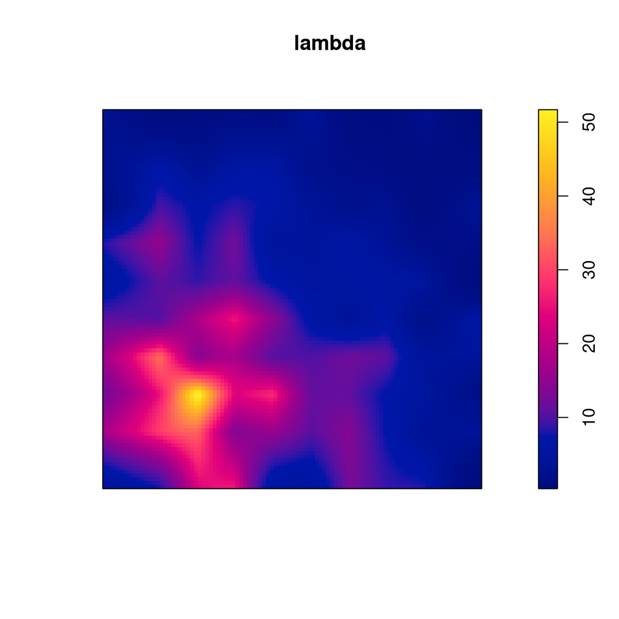

```r
# Definimos las betas que vamos a utilizar
beta0 <- 3
beta1 <- -0.9
beta2 <- 0.15

# Creamos una función que, tomando los valores de dwat y forest, nos calcule
# la lambda según nuestra fórmula
ff <- function(dwat,forest){exp(beta0 + (beta1*(dwat)) + (beta2*(forest)))}

# Ejecutamos la función y visualizamos el resultado
rotate <- function(x) t(apply(x, 2, rev))
lambda <- as.im(rotate(matrix(ff(dwat[],forest[]),100,100, byrow=TRUE)))
plot(lambda)
```

Ya disponemos del parámetro $\lambda$ para cada una de las celdas de nuestro área de estudio. Para simular nuestra población tan solo tenemos que ejecutar la función `rpoispp` del paquete `spatstat`, la cual genera un patrón de puntos siguiento un proceso de Poisson dad0 un valor de $\lambda$.

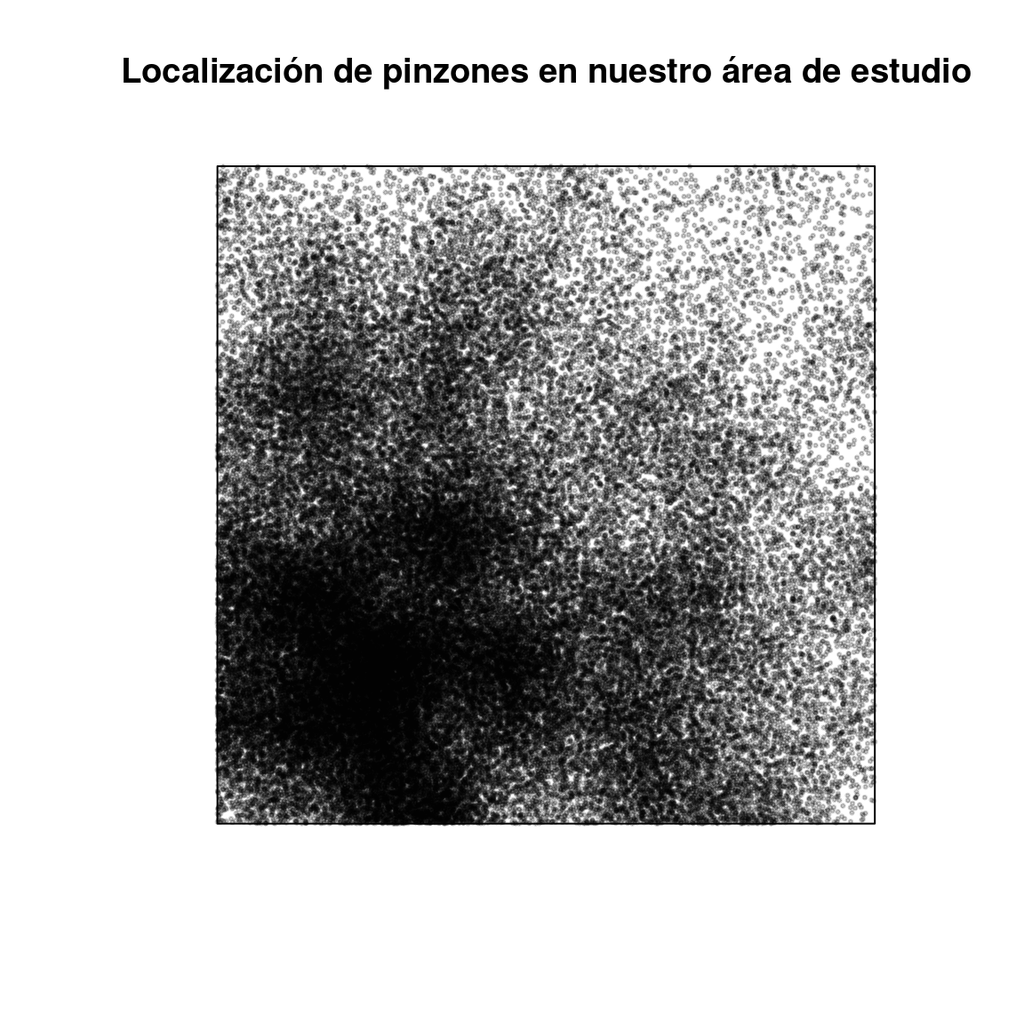

```r
pinzones <- rpoispp(lambda)
plot(pinzones, cex = 0.3, pch=19, main = "Localización de pinzones en nuestro área de estudio")
```

```r
pinzones
```

```
## Planar point pattern: 87628 points
## window: rectangle = [0.5, 100.5] x [0.5, 100.5] units
```

Podemos ahora realizar diferentes visualizaciones de nuestros datos, como dividir nuestro área de estudio en 100 cuadrículas de 10x10 kilómetros y contar el número de pinzones. O crear una función de densidad en 3 dimensiones que represente la abundancia de pinzones en nuestro área de estudio.

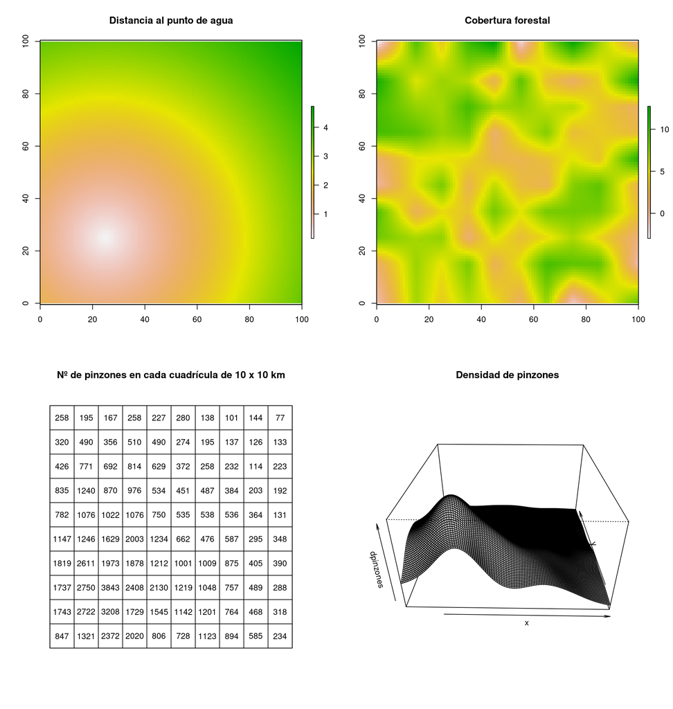

```r
# Dividimos el área de estudio en 100 cuadrículas de 10x10km y contamos los pinzones en su interior
Q10 <- quadratcount(pinzones, nx = 10, ny = 10)
# Calculamos una función de densidad de pinzones
dpinzones <- density(pinzones, sigma = 7)
# Visualizamos las covariables ambientales y la distribución de los pinzones
par(mfrow = c(2,2))
plot(dwat, main = "Distancia al punto de agua")
plot(forest, main = "Cobertura forestal")
plot(Q10, main = "Nº de pinzones en cada cuadrícula de 10 x 10 km")
persp(dpinzones, theta = 1, phi = 30, main = "Densidad de pinzones")
```

# Muestreo de la población

Una vez hemos generado nuestra población, llega el momento de salir a muestrearla. Para ello, un único ornitólogo, experto en fingílidos, ha salido al campo y ha realizado estaciones de escucha en 50 cuadrículas aleatorias a las 7:00 AM. Como nuestro ornitólogo es muy experto, ha sido capaz de detectar absolutamente todos los pinzones en cada cuadrícula a partir de la escucha de sus cantos y reclamos (pincha [aquí](https://www.youtube.com/watch?v=1WiOhpRj7rg) para escuchar cómo canta el pinzón vulgar). Además de anotar el número de aves, el investigador ha tomado nota de la cobertura forestal y de la distancia al punto de agua en esos 50 puntos. A continuación vamos a realizar el proceso de muestreo y generaremos una tabla con los datos anotados en nuestro campo *virtual*.

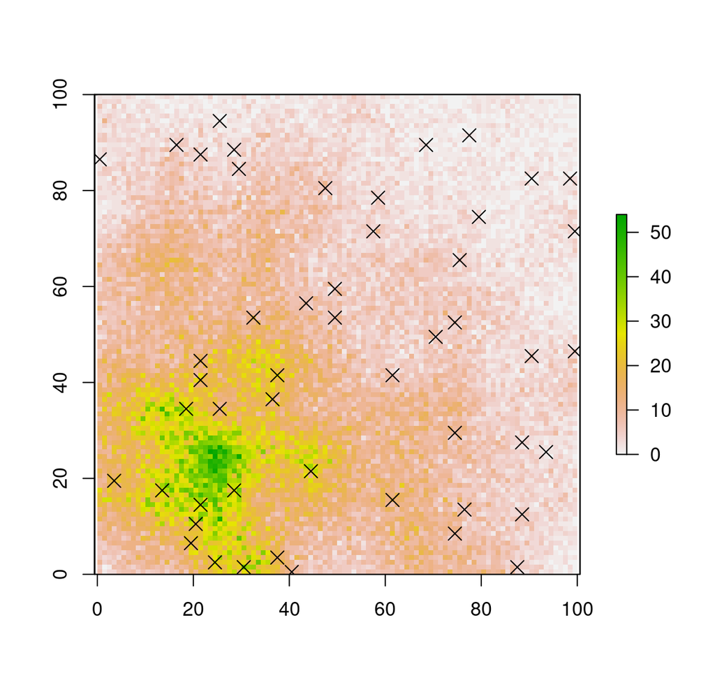

```r
# Primero vamos a almacenar el número de pinzones de cada celda en la capa
# raster de nuestro área de estudio que dejamos vacía inicialmente. Trabajar con
# capas raster nos facilitará las tareas posteriores.
Q100 <- quadratcount(pinzones, nx = 100, ny = 100)
sarea[] <- Q100

# Seleccionamos 50 cuadrículas de nuestro area de estudio al azar
set.seed(1)
sitioID <- sample(1:10000, 50)

# Visualizamos nuestros puntos de muestreo en nuestro área de estudio
plot(sarea)
points(xyFromCell(sarea, sitioID), pch = 4, cex = 1.5)
```

```r
# A continuación crearemos un data.frame (tabla) que tendrá las siguientes
# columnas: El ID del sitio, el número de pinzones detectados, la distancia al
# punto del agua y la cobertura forestal. La tabla tendrá 50 filas, una por
# cada sitio
dataset <- data.frame(sitioID)
dataset$pinzonesObs <- extract(sarea,sitioID)
dataset$dwat <- extract(dwat,sitioID)
dataset$forest <- extract(forest,sitioID)

# Visualizamos los primeros 20 registros
dataset[1:20,]
```

```
##    sitioID pinzonesObs      dwat    forest
## 1     1017           3 2.9651689  6.372694
## 2     8004          19 1.0932401  5.022489
## 3     4775           7 2.5969565  5.691176
## 4     9725          29 1.1069181  4.070826
## 5     8462          17 1.7711602  7.921080
## 6     4050           5 1.9719660  2.649831
## 7     8789           4 2.9503628  6.388420
## 8     1301           2 3.0150743 10.137109
## 9     8522          33 0.6074389  5.523570
## 10    1799           4 4.1993563  9.142346
## 11    9941           9 1.3901540  5.490673
## 12    8229          29 0.4855341  5.733672
## 13    1129           3 2.9013546  6.559836
## 14    8921          19 0.7871084  5.580598
## 15     878           2 3.8240862  6.079565
## 16    8677           4 2.4284949  8.026211
## 17    7845          20 0.9892737  4.073718
## 18    5922          20 0.8180277  5.481889
## 19    6526          11 0.5395397  4.539709
## 20    5071           3 2.3808299  4.797593
```

# Ajuste de un modelo general lineal

Con estos 50 datos, podríamos intentar ajustar un modelo. Es decir, podríamos relacionar la abundancia de pinzones (nuestra variable respuesta), con los datos que hemos tomado de distancia al punto de agua y de cobertura vegetal (nuestros predictores). A partir de los resultados, podríamos intetar hacer inferencias sobre cómo afectan estos dos factores a la abundancia de pinzones.

```r
# Utilizaremos un modelo general lineal

m1 <- glm(pinzonesObs ~ dwat + forest, family = poisson(link = "log"), data = dataset)
summary(m1)
```

```
##
## Call:
## glm(formula = pinzonesObs ~ dwat + forest, family = poisson(link = "log"),
##     data = dataset)
##
## Deviance Residuals:
##     Min       1Q   Median       3Q      Max
## -3.8009  -1.0072  -0.4590   0.8782   4.6890
##
## Coefficients:
##             Estimate Std. Error z value Pr(>|z|)
## (Intercept)  3.69246    0.17152  21.528   <2e-16 ***
## dwat        -0.84340    0.05144 -16.395   <2e-16 ***
## forest       0.02722    0.03134   0.868    0.385
## ---
## Signif. codes:  0 '***' 0.001 '**' 0.01 '*' 0.05 '.' 0.1 ' ' 1
##
## (Dispersion parameter for poisson family taken to be 1)
##
##     Null deviance: 441.76  on 49  degrees of freedom
## Residual deviance:  98.58  on 47  degrees of freedom
## AIC: 289.64
##
## Number of Fisher Scoring iterations: 5
```

En el resumen de nuestro modelo, los “Estimates” son las estimas de las $\beta$ de nuestro modelo, siendo el intercepto la $\beta_0$, y las otras dos las $\beta$ correspondientes a los predictores “distancia al punto de agua” y “cobertura forestal” respectivamente. Es aquí donde cobra sentido la simulación. Como en realidad fuimos nosotros quienes simulamos el proceso mediante el cual distribuímos a nuestros pinzones, tenemos acceso a los *estimates* simuladas con los que la abundancia de pinzones fue creada. Ahora, ¡podemos comparar los *estimates* simuladas con los que hemos obtenido a partir de nuestro modelo! De esta forma podemos comprobar si nuestro modelo que hemos creado a partir de 50 puntos de muestreo aleatorios es capaz de realizar unas buenas estipas de las *betas*. Recordamos cuales eran las betas con las que simulamos a nuestros pinzones:

### $\beta$’s simuladas

- Intercepto $\beta_{0} = 3$
- Distancia al punto de agua $\beta_{1} = -0.9$
- Cobertura forestal $\beta_{2} = 0.15$

### $\beta$’s estimadas por el modelo

- Intercepto $\beta_{0} = 3.69246$
- Distancia al punto de agua $\beta_{1} = -0.84340$
- Cobertura forestal $\beta_{2} = 0.02722$

Como podemos ver, nuestro modelo obteiene buenas estimas para el efecto de la distancia al punto de agua (-0.84 vs -0.9). Sin embargo, obtenemos una sobre estima en el intercepto, mientras que infraestimamos el efecto de la cobertura forestal.

Como ya hemos aprendido, los modelos nos pueden ayudar a comprender mejor un sistema complejo (poder explicativo), pero también para realizar predicciones. Con los *estimates* obtenidos podemos resolver la ecuación del modelo para predecir el número de pinzores en función a nuestras covariables predictoras. Recordamos que

$$\begin{equation}
\tag{Eq 4}\label{eq4}
\lambda = exp(\beta_0 - (\beta_1 * dwat) + (\beta_2 * forest))
\end{equation}$$

Si sustituimos las $\beta$’s de esa ecuación por los coeficientes estimados por nuestro modelo, podremos realizar predicciones sobre el número de pinzones en función de la distancia al punto de agua y de la cobertura forestal.

### Ecuación predictora de nuestro modelo

$$\begin{equation}
\tag{Eq 5}\label{eq5}
\lambda = exp(3.69246 - (0.84340 * dwat) + (0.02722 * forest))
\end{equation}$$

Imaginamos un punto que está a una distancia de 4 unidades del punto de agua, y que tiene una cobertura forestal de 15 unidades. Podremos predecir (en base a nuestro modelo), el número de pinzones de ese lugar si resolvemos la ecuación

$$\begin{equation}
\tag{Eq 6}\label{eq6}
\lambda = exp(3.69246 - (0.84340 * 4) + (0.02722 * 15))
\end{equation}$$

```r
# Resolvemos la ecuación
exp(3.69246 - (0.84340 * 4) + (0.02722 * 15))
```

```
## [1] 2.069196
```

Nuestro modelo predice que en ese lugar habrá 2 pinzones. De esta forma, podemos predecir el número de gorriones en cada uno de nuestros puntos de muestreo. Una forma rápida de hacerlo es utlizar la función `predict`. Después podremos comparar los valores predichos frente a los realmente observados.

```r
# Predecimos el número de pinzones en nuestros puntos de muestreo
dataset$predM1 <- predict(m1, dataset, type = "response")
dataset[1:10,]
```

```
##    sitioID pinzonesObs      dwat    forest    predM1
## 1     1017           3 2.9651689  6.372694  3.916099
## 2     8004          19 1.0932401  5.022489 18.304237
## 3     4775           7 2.5969565  5.691176  5.244062
## 4     9725          29 1.1069181  4.070826 17.631594
## 5     8462          17 1.7711602  7.921080 11.181632
## 6     4050           5 1.9719660  2.649831  8.177855
## 7     8789           4 2.9503628  6.388420  3.967006
## 8     1301           2 3.0150743 10.137109  4.159822
## 9     8522          33 0.6074389  5.523570 27.952251
## 10    1799           4 4.1993563  9.142346  1.491182
```

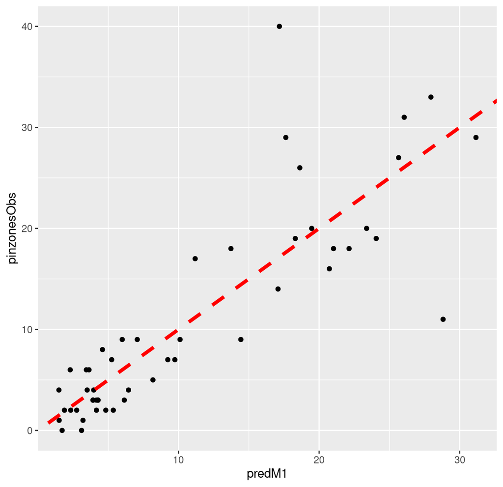

```r
# Comparamos nuestros valores predichos frente a los valores realmente observados

ggplot(dataset, aes(x = predM1, y = pinzonesObs)) + geom_point() +
  geom_abline(intercept = 0, slope = 1, color="red", linetype="dashed", size=1.5)
```

Nuestras predicciones se acercan bastante a nuestros valores observados. Por lo tanto, podríamos decir que aunque los $\beta$’s estimados a partir del modelo no se corresponden exactamente con los $\beta$’s simulados, estas desviaciones no afectan demasiado a las predicciones del modelo.

# Ejercicios

1. Realiza un nuevo muestreo de otros 100 puntos para obtener los valores de las covariables predictoras y los pinzones observados. Compara estos 100 nuevos datos con las predicciones de la abundancia de pinzones de nuestros modelos en estos lugares.
2. Utilizando los dos rasters *“dwat”* y *“forest”*, realiza una predicción espacialmente explícita del número de pinzones para todo tu área de estudio (mapa de abundancias).